# Supplementary Myoid

Salvatore Lorenzo Renne

8/21/2020

# Supplementary material

## Research strategy

A systematic literature search was performed on December 9th, 2019 in Medline and Web of Science databases according to the following search strategy MEDLINE: myoid[All Fields] AND (“testicular neoplasms”[MeSH Terms] OR (“testicular”[All Fields] AND “neoplasms”[All Fields]) OR “testicular neoplasms”[All Fields] OR (“tumor”[All Fields] AND “testis”[All Fields]) OR “tumor testis”[All Fields]) Web of Science: TOPIC: (myoid tumor testis). Timespan: All years. Indexes: SCI-EXPANDED, SSCI, A&HCI, CPCI-S, CPCI-SSH, ESCI

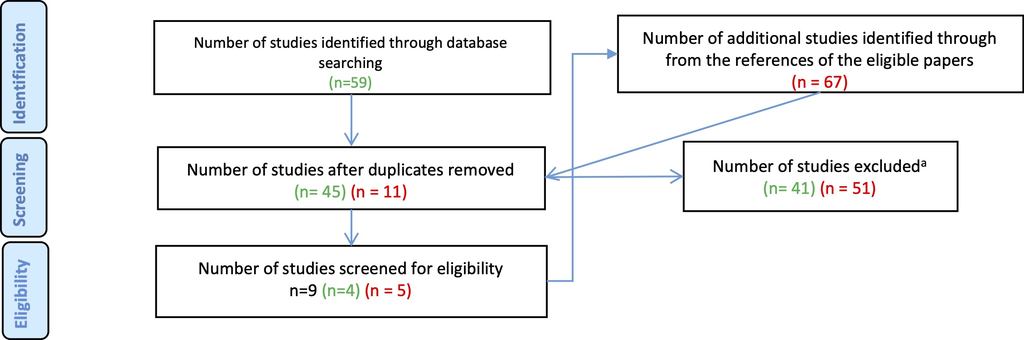

Search strategy flow chart

## Age model

### Prior predictive simulations

We modeled age $A_i$ as normally distributed, with mean $\mu$ and $\sigma$.
$$A_i \sim Normal( \mu, \sigma)$$
We looked for a prior distribution with a mean *compatible* with human age. We simulated several normal distribution:

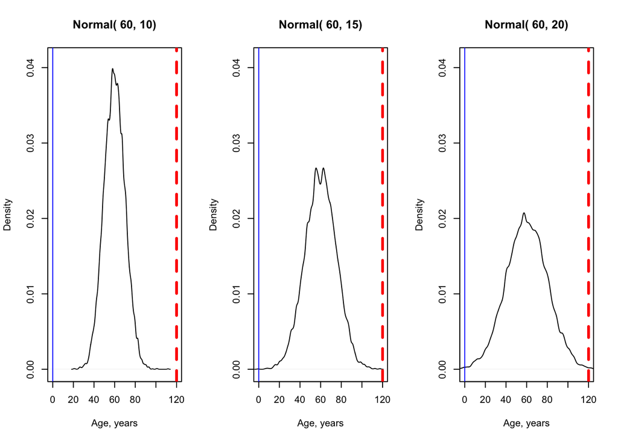

Prior predictive simulation for age. The vertical lines indicate 0 and 120 years.

For $\mu$ we chose a $Normal(60, 20)$ that put most of the mass of the mean in the a plausible range. We chose a $Exponential(1)$ prior for the standard deviation $\sigma$ for maximum entropy reason.

### Model coefficients

Inference for Stan model: 4 chains, each with iter=1000; warmup=500; thin=1;post-warmup draws per chain=500, total post-warmup draws=2000.

| Parameter | mean | sd | 5.5% | 94.5% | n_eff | $\hat{R}$ |
| --- | --- | --- | --- | --- | --- | --- |
| $\mu$ | 37.87 | 2.82 | 33.45 | 42.39 | 1047 | 1 |
| $\sigma$ | 11.39 | 1.45 | 9.35 | 13.90 | 1194 | 1 |

Samples were drawn using NUTS. For each parameter, n_eff is a crude measure of effective sample size, and $\hat{R}$ is the potential scale reduction factor on split chains (at convergence, $\hat{R}$=1).

## Size Model

### Prior predictive simulations

Similarly, we modeled size $S_i$ as normally distributed, with mean $\mu$ and $\sigma$.
$$S_i \sim Normal( \mu, \sigma)$$
Again with prior predictive simulation we looked for a prior distribution with a mean *compatible* with the meaning of size (i.e. most of the mass would not be non-negative). We simulated several normal distribution:

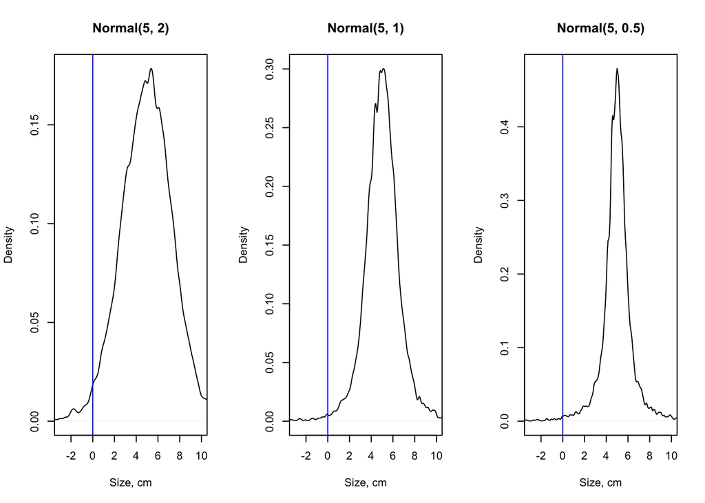

Prior predictive simulation for size. The vertical lines indicate 0 cm.

For $\mu$ we chose a $Normal(5, 0.75)$ that put most of the mass of the mean in the a plausible range. We chose a $Exponential(1)$ prior for the standard deviation $\sigma$ for maximum entropy reason.

### Model coefficients

Inference for Stan model: 4 chains, each with iter=1000; warmup=500; thin=1;post-warmup draws per chain=500, total post-warmup draws=2000.

| Parameter | mean | sd | 5.5% | 94.5% | n_eff | $\hat{R}$ |
| --- | --- | --- | --- | --- | --- | --- |
| $\mu$ | 2.82 | 0.33 | 2.35 | 3.39 | 809 | 1.01 |
| $\sigma$ | 1.32 | 0.28 | 0.96 | 1.82 | 731 | 1.01 |

## Mitosis Model

### Prior predictive simulations

Similarly, we modeled size $M_i$ as zero inflated Poisson (ZIPoisson) with rate $\lambda$; the zero inflated Poisson is a type of model that is used in [ecology](https://www.jstor.org/stable/27650840?seq=1):
$$\begin{equation}
M_i \sim ZIPoisson(p_i, \lambda_i)\\
logit(p_i) = \alpha_p\\
log(\lambda_i) = \alpha_\lambda\\
\alpha_p \sim Normal(-1.5, 1)\\
\alpha_\lambda \sim Normal(0.5, 0.5)
\end{equation}$$

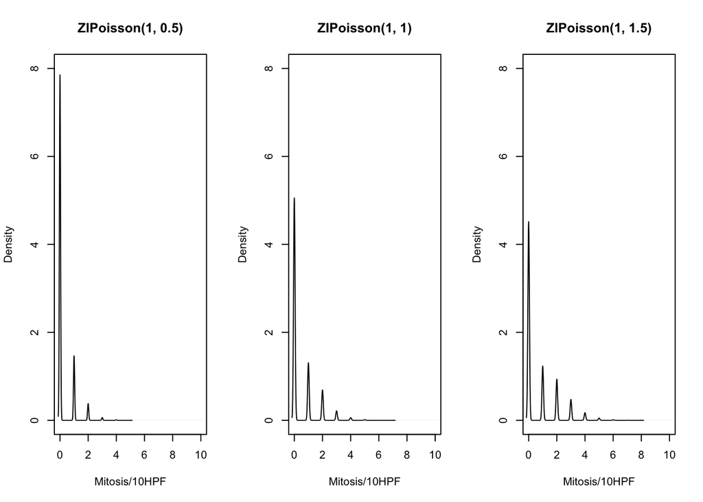

Prior predictive simulation for mitotis.

We chose as a prior for $\alpha_p$ a $Normal(-1.5, 1)$, since we expeted more often than not to see mitosis; on the other hand we chose $Normal(0.5, 0.5)$ for $\alpha_\lambda$ since we exected a low mitotic activity.

### Model coefficients

Inference for Stan model: 4 chains, each with iter=1000; warmup=500; thin=1;post-warmup draws per chain=500, total post-warmup draws=2000.

| Parameter | mean | sd | 5.5% | 94.5% | n_eff | $\hat{R}$ |
| --- | --- | --- | --- | --- | --- | --- |
| $\alpha_p$ | -0.38 | 0.56 | -1.28 | 0.45 | 1155 | 1 |
| $\alpha_\lambda$ | 1.08 | 0.22 | 0.72 | 1.42 | 1083 | 1 |